# Tanzania Poverty Measurement (2012 vs 2018)

Group: Alona Sycheska

# 1 Data & Methods

## 1.1 Files and variables

The provided HHBS extracts: - `Tanzania_2012.dta` - `Tanzania_2018.dta`

Key variables: - `STRATUM` (stratum: rural, other urban, Dar es Salaam)  
- `hhweight` (household sampling weight)  
- `region` (region name)  
- `hhsize` (household size)  
- `cons` (consumption per equivalent adult — welfare indicator)  
- `povline` (standard poverty line)  
- `food_povline` (food poverty line)  
- `year` (survey year)  
- plus other descriptive variables (e.g., `sex_hhh`, `educlevel_hhh`)

For the assignment, *people* are weighted, not households: person weight = `hhweight * hhsize`.

## 1.2 Load data

```r
d12 <- read_dta("Tanzania_2012.dta") %>% mutate(year = 2012)
d18 <- read_dta("Tanzania_2018.dta") %>% mutate(year = 2018)

# keep common columns
common_cols <- intersect(names(d12), names(d18))
d12 <- d12 %>% select(all_of(common_cols))
d18 <- d18 %>% select(all_of(common_cols))

dall <- bind_rows(d12, d18) %>%
  mutate(
    region   = as.character(region),
    STRATUM  = as.character(STRATUM),
    hhsize   = as.numeric(hhsize),
    hhweight = as.numeric(hhweight),
    cons     = as.numeric(cons),
    povline  = as.numeric(povline),
    food_povline = as.numeric(food_povline),
    pw       = hhweight * hhsize   # person-weight
  ) %>%
  filter(!is.na(cons), !is.na(pw), pw > 0)

dall %>% count(year) %>% kable() %>% kable_styling(full_width = FALSE)
```

| year | n |
| --- | --- |
| 2012 | 10186 |
| 2018 | 9463 |

## 1.3 FGT definitions

Foster–Greer–Thorbecke measures with weighted data. For a poverty line `z`, welfare `y`, weights `w`:

- Headcount: $P_0 = \frac{\sum w \cdot I(y<z)}{\sum w}$
- Poverty gap: $P_1 = \frac{\sum w \cdot ((z - y)/z) \cdot I(y<z)}{\sum w}$
- Squared gap: $P_2 = \frac{\sum w \cdot ((z - y)/z)^2 \cdot I(y<z)}{\sum w}$

```r
fgt_vec <- function(y, z, w, alpha = 0) {
  poor <- y < z & !is.na(y) & !is.na(z)
  if (!any(poor, na.rm = TRUE)) return(0)
  gap <- pmax(0, (z - y) / z)
  num <- sum(w * (gap ^ alpha) * poor, na.rm = TRUE)
  den <- sum(w, na.rm = TRUE)
  if (den == 0) return(NA_real_)
  num / den
}

fgt_all <- function(df, zvar = "povline", w = "pw", y = "cons") {
  z <- df[[zvar]]
  yv <- df[[y]]
  ww <- df[[w]]
  tibble(
    P0 = fgt_vec(yv, z, ww, 0),
    P1 = fgt_vec(yv, z, ww, 1),
    P2 = fgt_vec(yv, z, ww, 2)
  )
}
```

# 2 Results

## 2.1 A) National poverty (standard and food lines)

```r
# national poverty indices  (P0, P1, P2)
# for both the standard and food lines

# standard poverty line
nat_std <- dall %>%
  group_by(year) %>%
  summarise(
    total_weight = sum(pw, na.rm = TRUE),
    P0 = sum(pw[cons < povline], na.rm = TRUE) / total_weight,
    P1 = sum(pw * ((povline - cons) / povline) * (cons < povline), na.rm = TRUE) / total_weight,
    P2 = sum(pw * ((povline - cons) / povline)^2 * (cons < povline), na.rm = TRUE) / total_weight
  ) %>%
  mutate(line = "Standard")

# food poverty line
nat_food <- dall %>%
  group_by(year) %>%
  summarise(
    total_weight = sum(pw, na.rm = TRUE),
    P0 = sum(pw[cons < food_povline], na.rm = TRUE) / total_weight,
    P1 = sum(pw * ((food_povline - cons) / food_povline) * (cons < food_povline), na.rm = TRUE) / total_weight,
    P2 = sum(pw * ((food_povline - cons) / food_povline)^2 * (cons < food_povline), na.rm = TRUE) / total_weight
  ) %>%
  mutate(line = "Food")

nat_all <- bind_rows(nat_std, nat_food)


kable(nat_all %>% mutate(across(P0:P2, ~ percent(., 0.1))),
      caption = "National poverty indices (P0, P1, P2) by year and poverty line") %>%
  kable_styling(full_width = FALSE)
```

National poverty indices (P0, P1, P2) by year and poverty line

| year | total_weight | P0 | P1 | P2 | line |
| --- | --- | --- | --- | --- | --- |
| 2012 | 42270137 | 28.2% | 6.7% | 2.3% | Standard |
| 2018 | 52679833 | 26.4% | 6.2% | 2.1% | Standard |
| 2012 | 42270137 | 9.7% | 1.8% | 0.6% | Food |
| 2018 | 52679833 | 8.0% | 1.4% | 0.4% | Food |

### 2.1.1 Interpretation

```
## Between 2012 and 2018: Headcount (P0) fell from 28.2% to 26.4%; Poverty gap (P1) from 6.7% to 6.2%; and Squared gap (P2) from 2.3% to 2.1%.
```

## 2.2 B) Stratum poverty (rural, other urban, Dar es Salaam)

```r
# FGT indices for both poverty lines
stratum_all <- dall %>%
  mutate(
    pov_type = "Standard",
    pov_used = povline
  ) %>%
  bind_rows(
    dall %>%
      mutate(
        pov_type = "Food",
        pov_used = food_povline
      )
  ) %>%
  group_by(year, STRATUM, pov_type) %>%
  summarise(
    total_weight = sum(pw, na.rm = TRUE),

    # FGT0: Headcount (%)
    P0 = round(100 * sum(pw * (cons < pov_used), na.rm = TRUE) / total_weight, 1),

    # FGT1: Poverty Gap (%)
    P1 = round(
      100 * sum(pw * ((pov_used - cons) / pov_used) * (cons < pov_used),
                na.rm = TRUE) / total_weight,
      1
    ),

    # FGT2: Squared Poverty Gap (%)
    P2 = round(
      100 * sum(pw * ((pov_used - cons) / pov_used)^2 * (cons < pov_used),
                na.rm = TRUE) / total_weight,
      1
    ),
    .groups = "drop"
  )

head(stratum_all)
```

| year | STRATUM | pov_type | total_weight | P0 | P1 | P2 |
| --- | --- | --- | --- | --- | --- | --- |
| 2012 | 1 | Food | 30084695 | 11.3 | 2.1 | 0.6 |
| 2012 | 1 | Standard | 30084695 | 33.3 | 7.8 | 2.7 |
| 2012 | 2 | Food | 7922945 | 8.7 | 1.9 | 0.6 |
| 2012 | 2 | Standard | 7922945 | 21.7 | 5.5 | 2.1 |
| 2012 | 3 | Food | 4262497 | 1.0 | 0.2 | 0.1 |
| 2012 | 3 | Standard | 4262497 | 4.1 | 0.8 | 0.3 |

### 2.2.1 Interpretation

[output not shown]

## 2.3 C) Region poverty

```r
region_std <- dall %>% group_by(year, region) %>%
  group_modify(~ fgt_all(.x, zvar = "povline")) %>% ungroup() %>%
  mutate(line = "Standard")

region_food <- dall %>% group_by(year, region) %>%
  group_modify(~ fgt_all(.x, zvar = "food_povline")) %>% ungroup() %>%
  mutate(line = "Food")

region_all <- bind_rows(region_std, region_food)


kable(region_all %>% arrange(year, line, region) %>%
        mutate(across(P0:P2, ~ percent(., accuracy = 0.1))) %>%
        group_by(year, line) %>% slice_head(n = 5) %>% ungroup(),
      caption = "Region-level poverty (first 5 rows per year/line)") %>%
  kable_styling(full_width = FALSE)
```

Region-level poverty (first 5 rows per year/line)

| year | region | P0 | P1 | P2 | line |
| --- | --- | --- | --- | --- | --- |
| 2012 | 1 | 9.9% | 1.4% | 0.3% | Food |
| 2012 | 10 | 24.4% | 5.8% | 2.2% | Food |
| 2012 | 11 | 18.2% | 2.7% | 0.7% | Food |
| 2012 | 12 | 7.7% | 1.3% | 0.4% | Food |
| 2012 | 13 | 15.5% | 2.9% | 0.7% | Food |
| 2012 | 1 | 34.6% | 7.1% | 2.1% | Standard |
| 2012 | 10 | 53.7% | 15.6% | 6.3% | Standard |
| 2012 | 11 | 43.0% | 11.0% | 3.7% | Standard |
| 2012 | 12 | 32.1% | 7.0% | 2.1% | Standard |
| 2012 | 13 | 33.6% | 8.8% | 3.2% | Standard |
| 2018 | 1 | 3.7% | 0.7% | 0.2% | Food |
| 2018 | 10 | 6.6% | 1.0% | 0.3% | Food |
| 2018 | 11 | 6.1% | 0.9% | 0.2% | Food |
| 2018 | 12 | 6.8% | 1.0% | 0.3% | Food |
| 2018 | 13 | 9.3% | 1.3% | 0.3% | Food |
| 2018 | 1 | 23.2% | 4.1% | 1.2% | Standard |
| 2018 | 10 | 30.6% | 6.7% | 2.1% | Standard |
| 2018 | 11 | 19.5% | 4.3% | 1.4% | Standard |
| 2018 | 12 | 21.1% | 4.7% | 1.6% | Standard |
| 2018 | 13 | 34.0% | 7.4% | 2.3% | Standard |

### 2.3.1 Interpretation

```
## -  Regional results show heterogeneity: some areas improve, others worsen.
## - This confirms that national averages can hide large geographic disparities in poverty outcomes.
```

# 3 Visualization: National Trends

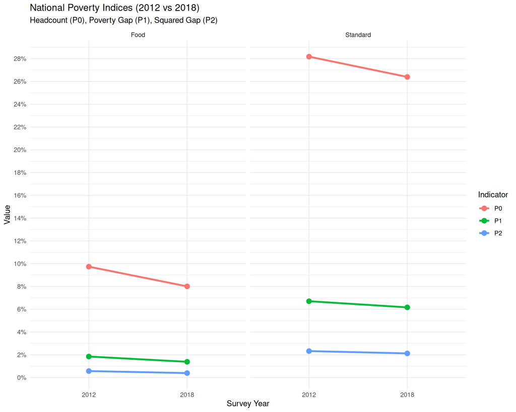

```r
# plot national poverty indices
nat_all %>%
  pivot_longer(P0:P2, names_to = "Indicator", values_to = "Value") %>%
  ggplot(aes(x = factor(year), y = Value, color = Indicator, group = Indicator)) +
  geom_line(size = 1.2) +
  geom_point(size = 3) +
  facet_wrap(~ line) +
  scale_y_continuous(
    labels = percent_format(accuracy = 1),
    breaks = seq(0, 0.35, by = 0.02)
  ) +
  labs(
    title = "National Poverty Indices (2012 vs 2018)",
    subtitle = "Headcount (P0), Poverty Gap (P1), Squared Gap (P2)",
    x = "Survey Year",
    y = "Value",
    color = "Indicator"
  ) +
  theme_minimal()
```

# 4 Contributions to national headcount

```r
contrib_share <- function(df, zvar = "povline", w = "pw", y = "cons", group_vars) {
  z <- df[[zvar]]; yv <- df[[y]]; ww <- df[[w]]
  df %>%
    mutate(poor = as.integer(yv < z)) %>%
    group_by(across(all_of(c("year", group_vars)))) %>%
    summarise(poor_pop = sum(ww * poor, na.rm = TRUE), .groups = "drop") %>%
    group_by(year) %>%
    mutate(contrib_share = poor_pop / sum(poor_pop)) %>%
    ungroup()
}

stratum_contrib <- contrib_share(dall, zvar = "povline", group_vars = "STRATUM")
region_contrib  <- contrib_share(dall, zvar = "povline", group_vars = "region")

kable(stratum_contrib %>% arrange(year, desc(contrib_share)) %>%
        mutate(contrib_share = percent(contrib_share, 0.1)),
      caption = "Stratum contribution to national poor (standard line)") %>%
  kable_styling(full_width = FALSE)
```

Stratum contribution to national poor (standard line)

| year | STRATUM | poor_pop | contrib_share |
| --- | --- | --- | --- |
| 2012 | 1 | 24761758 | 63.6% |
| 2012 | 2 | 11532493 | 29.6% |
| 2012 | 3 | 2632349 | 6.8% |
| 2018 | 1 | 23640872 | 55.1% |
| 2018 | 2 | 14093023 | 32.8% |
| 2018 | 3 | 5190217 | 12.1% |

```r
kable(region_contrib %>% group_by(year) %>%
        arrange(year, desc(contrib_share), .by_group = TRUE) %>%
        slice_head(n = 7) %>% ungroup() %>%
        mutate(contrib_share = percent(contrib_share, 0.1)),
      caption = "Top 7 region contributions to national poor (standard line)") %>%
  kable_styling(full_width = FALSE)
```

Top 7 region contributions to national poor (standard line)

| year | region | poor_pop | contrib_share |
| --- | --- | --- | --- |
| 2012 | 16 | 39203853 | 11.3% |
| 2012 | 10 | 35197618 | 10.1% |
| 2012 | 9 | 27572472 | 7.9% |
| 2012 | 11 | 24553776 | 7.1% |
| 2012 | 13 | 24283915 | 7.0% |
| 2012 | 1 | 20590212 | 5.9% |
| 2012 | 17 | 20471604 | 5.9% |
| 2018 | 8 | 29802586 | 7.8% |
| 2018 | 14 | 29362431 | 7.7% |
| 2018 | 16 | 29068150 | 7.6% |
| 2018 | 17 | 27122509 | 7.1% |
| 2018 | 10 | 26518774 | 6.9% |
| 2018 | 15 | 26443068 | 6.9% |
| 2018 | 13 | 24654033 | 6.4% |